# TAD_analysis

```python
import pandas as pd
import numpy as np
import matplotlib.pyplot as plt
import matplotlib as mpl
%matplotlib inline
import seaborn as sns; sns.set(color_codes=True)
from IPython.core.interactiveshell import InteractiveShell
InteractiveShell.ast_node_interactivity = "all"
```

#### Data from 2016 Schmitt paper found in /dors/capra_lab/users/bentonml/enhancer_gain_loss/data/reg_domains/tad

```python
import csv
with open('/dors/capra_lab/users/evonne/TAD/data/schmitt16_cellTypes_fileLocs.txt') as f:
    reader = csv.reader(f, delimiter = "\t")
    input_file_list = list(reader)

cell_type_tads = {}

for line in input_file_list:
    cell_type_tads[line[1]] = pd.read_table(line[0], header=0)
    cell_type_tads[line[1]].columns = ['chr','start','stop']

# access data frames in the dictionary like this: cell_type_tads['bladder'].head()
```

### Number of TAD boundaries in each cell type

```python
sum = 0

for key in cell_type_tads:
    print(key + ":   " + str(len(cell_type_tads[key])))
    sum = sum + len(cell_type_tads[key])


print("\n\n\n" + str(sum) + " number of NON unique TADs over 21 unique tissue/cell types")
```

```
adrenal:   2147
aorta:   2043
bladder:   2147
cortex:   2193
lymphoblast:   2305
embryonic_stem_cell:   2501
hippocampus:   2203
fibroblast:   2230
lung:   2257
liver:   2271
left_ventricle:   2078
mesoderm:   2478
mesenchymal_stem_cell:   2289
neural_progenitor:   2377
ovary:   2163
pancreas:   2198
psoas_muscle:   2223
right_ventricle:   2082
small_bowel:   2194
spleen:   2334
trophoblast_like:   2434



47147 number of NON unique TADs over 21 unique tissue/cell types
```

### Some summary stats about the TAD boundaries

#### Function to find base pair size between two TADs

```python
def betweenTADsize(data_frame): # input: BED file coordinates

    diff = np.array([])

    for i in range(len(data_frame) - 1):
        if data_frame.loc[i + 1,'chr'] == data_frame.loc[i,'chr']:
            difference =  data_frame.loc[i + 1,'start'] - data_frame.loc[i,'stop']
            diff = np.append(diff, difference)

    return(pd.DataFrame(diff)) # returns data frame of the basepair size between TAD boundaries
```

```python
tads_merged  = pd.DataFrame(columns = ['chr','start','stop'])

for key in cell_type_tads:
    tads_merged = pd.merge(tads_merged,cell_type_tads[key],how='outer',sort=True)

tads_merged = tads_merged.drop_duplicates() # there shouldnt be any duplicates but drop them if there are
print(str(len(tads_merged)) + " number of UNIQUE TADs of 211 unique tissue/cell types if given no \"buffer\" for the start/stop location")
```

```
16744 number of UNIQUE TADs of 211 unique tissue/cell types if given no "buffer" for the start/stop location
```

### interTAD boundary distances by tissue/cell type

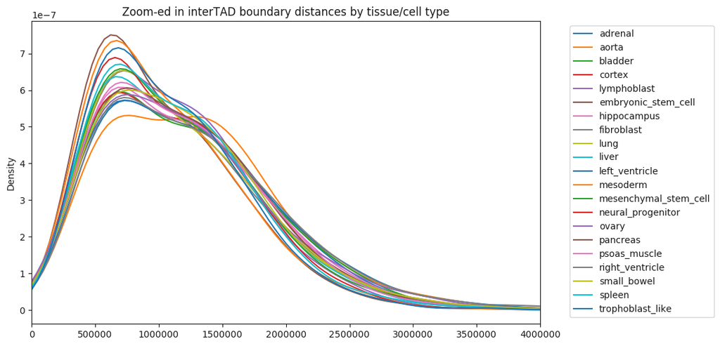

```python
mpl.style.use('default')
ax = plt.subplot(111)
for key in cell_type_tads:
    diff = betweenTADsize(cell_type_tads[key])
    diff.columns = [key]
    ax = diff.plot.kde(xlim =(0,4000000), figsize=(10,6), title='Zoom-ed in interTAD boundary distances by tissue/cell type', ax=ax)

#diff.describe()
ax.legend(loc='upper center', bbox_to_anchor=(1.2, 1))

plt.show()
```

### interTAD boundary distances on merged TAD set

|  | chr | start | stop |
| --- | --- | --- | --- |
| 0 | chr1 | 2400000 | 2440000 |
| 1 | chr1 | 2560000 | 2600000 |
| 2 | chr1 | 3320000 | 3360000 |
| 3 | chr1 | 3360000 | 3400000 |
| 4 | chr1 | 3400000 | 3440000 |
| 5 | chr1 | 3440000 | 3480000 |
| 6 | chr1 | 3480000 | 3520000 |
| 7 | chr1 | 3520000 | 3560000 |
| 8 | chr1 | 3560000 | 3600000 |
| 9 | chr1 | 3640000 | 3680000 |

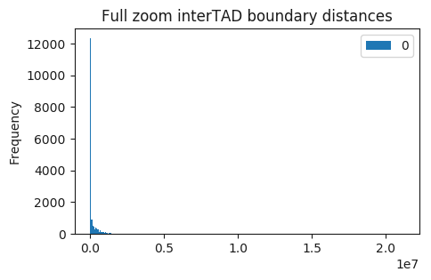

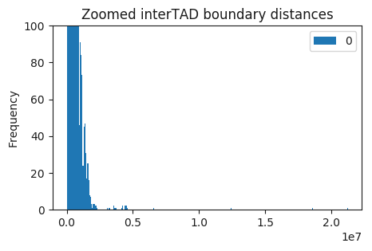

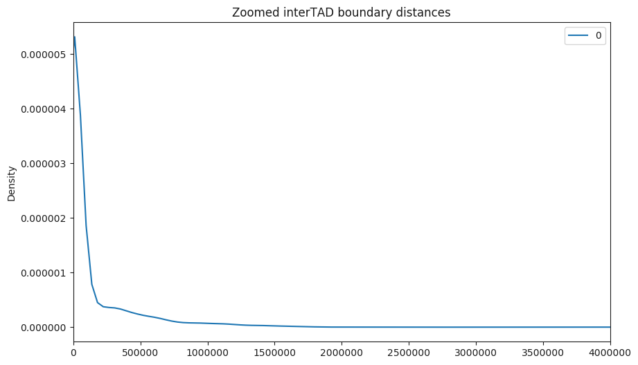

```python
tads_merged.head(10)
diff = betweenTADsize(tads_merged)
diff.plot.hist(bins=300, figsize=(5,3),title='Full zoom interTAD boundary distances')
diff.plot.hist(bins=300, figsize=(5,3),title='Zoomed interTAD boundary distances',ylim = (0,100))
diff.plot.kde(figsize=(10,6),title='Zoomed interTAD boundary distances', xlim =(0,4000000))
```

Note the big right tail end regions are likely spanning genomic "black list regions" (eg centromeres, highly repetitive sequence)

Note: some of the TAD boundaries probably truely represent the same TAD boundary but start/stop at a slightly different spot

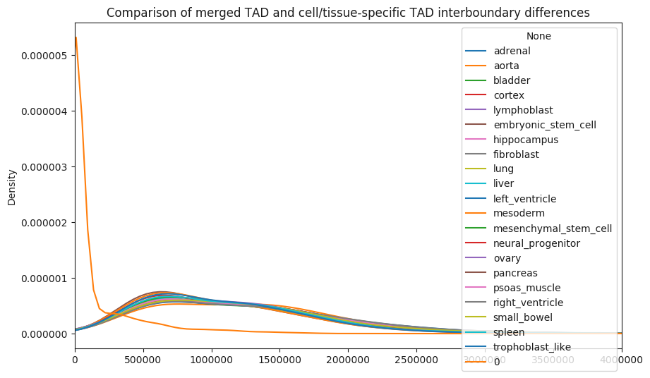

```python
#Same code copied from above and 2 graphs overlayed. There is a more elegant/clean way to do this
mpl.style.use('default')
ax = plt.subplot(111)
for key in cell_type_tads:
    diff = betweenTADsize(cell_type_tads[key])
    diff.columns = [key]
    ax = diff.plot.kde(xlim =(0,4000000), figsize=(10,6), ax=ax)

diff = betweenTADsize(tads_merged)
ax.legend(loc='upper center', bbox_to_anchor=(1.2, 1))
ax = diff.plot.kde(figsize=(10,6),title='Comparison of merged TAD and cell/tissue-specific TAD interboundary differences', xlim =(0,4000000),ax=ax)
plt.show()
```

Used the last plot to choose 200,000 as a buffer

#### Create one master TAD list with intervals for TAD start and stop sites

```python
def createMasterTADboundList(buffer, tads_merged):
    ## Input:
    # buffer: integer which is the window of the buffer (if you give 200KB you add 100kb and subtract 100kb to look for other TAD boundaries)
    # tads_merged: a list of all the TAD boundaries merged
    buffer = buffer*2
    tmp = tads_merged.copy(deep=True)
    TAD_master = []

    while len(tmp) != 0:
        start = tmp.loc[0,'start']
        stop = tmp.loc[0,'stop']
        chrom = tmp.loc[0,'chr']
        start_min = start - buffer
        start_max = start + buffer
        stop_min = stop - buffer
        stop_max = stop + buffer
        tmp.drop(tmp[(tmp['chr'] == chrom) & (tmp['start'] > start_min) & (tmp['start'] < start_max) & (tmp['stop'] > stop_min) & (tmp['stop'] < stop_max)].index, inplace=True)
        tmp = tmp.reset_index(drop=True)
        TAD_master.append([chrom,start_min,start_max,stop_min,stop_max])

    del tmp

    TAD_master = pd.DataFrame(np.vstack(TAD_master))
    TAD_master.columns = ['chr','start_min','start_max','stop_min','stop_max']

    TAD_master = TAD_master.apply(pd.to_numeric, errors = 'ignore')

    return(TAD_master)
```

```python
buffer = 200000
TAD_master_200k = createMasterTADboundList(buffer,tads_merged)
print(str(len(TAD_master_200k)) + " number of UNIQUE TADs of 21 unique tissue/cell types if given a " + str(buffer) + "bp \"buffer\" for the start/stop location")

buffer = 1
TAD_master = createMasterTADboundList(buffer,tads_merged)
print(str(len(TAD_master)) + " number of UNIQUE TADs of 21 unique tissue/cell types if given a " + str(buffer) + "bp \"buffer\" for the start/stop location")

buffer = 400000
TAD_master_400k = createMasterTADboundList(buffer,tads_merged)
print(str(len(TAD_master_400k)) + " number of UNIQUE TADs of 21 unique tissue/cell types if given a " + str(buffer) + "bp \"buffer\" for the start/stop location")
```

```
3793 number of UNIQUE TADs of 21 unique tissue/cell types if given a 200000bp "buffer" for the start/stop location
16744 number of UNIQUE TADs of 21 unique tissue/cell types if given a 1bp "buffer" for the start/stop location
2455 number of UNIQUE TADs of 21 unique tissue/cell types if given a 400000bp "buffer" for the start/stop location
```

```python
TAD_master.head()
print(str(len(TAD_master_200k)) + " number of UNIQUE TADs of 21 unique tissue/cell types if given a " + str(buffer) + "bp \"buffer\" for the start/stop location")
```

|  | chr | start_min | start_max | stop_min | stop_max |
| --- | --- | --- | --- | --- | --- |
| 0 | chr1 | 2399998 | 2400002 | 2439998 | 2440002 |
| 1 | chr1 | 2559998 | 2560002 | 2599998 | 2600002 |
| 2 | chr1 | 3319998 | 3320002 | 3359998 | 3360002 |
| 3 | chr1 | 3359998 | 3360002 | 3399998 | 3400002 |
| 4 | chr1 | 3399998 | 3400002 | 3439998 | 3440002 |

```
3793 number of UNIQUE TADs of 21 unique tissue/cell types if given a 400000bp "buffer" for the start/stop location
```

#### Function to run through a bed and add a column to the master TAD list, 1 represents that TAD does exist in the bed file, and 0 represents that it does not exist

TODO: rethink through this with TAD boundaries

```python
def findTADinCellTypes(data_frame, stringOfCellTypeName, TAD_total):
    ## Input:
    # data_frame: BED file coordinates data frame - cell type specific
    # stringOfCellTypeName: string describing the cell type name
    # TAD_total: dataframe of all merged TADs - the "master" list

    TAD_total[stringOfCellTypeName] = 0

    for i in range(len(data_frame)):
        index = TAD_total[(TAD_total['chr'] == data_frame.loc[i,'chr']) & (TAD_total['start_min'] < data_frame.loc[i,'start']) & (TAD_total['start_max'] > data_frame.loc[i,'start']) & (TAD_total['stop_min'] < data_frame.loc[i,'stop']) & (TAD_total['stop_max'] > data_frame.loc[i,'stop'])].index
        TAD_total.loc[index,stringOfCellTypeName] = 1
    return TAD_total
```

```python
#findTADinCellTypes(cell_type_tads['bladder'],'bladder',TAD_master).head()

for key in cell_type_tads:
    TAD_master_200k = findTADinCellTypes(cell_type_tads[key], key, TAD_master_200k)
    TAD_master = findTADinCellTypes(cell_type_tads[key], key, TAD_master)
    TAD_master_400k = findTADinCellTypes(cell_type_tads[key], key, TAD_master_400k)
```

```python
TAD_master.head()
```

[output not shown]

5 rows × 26 columns

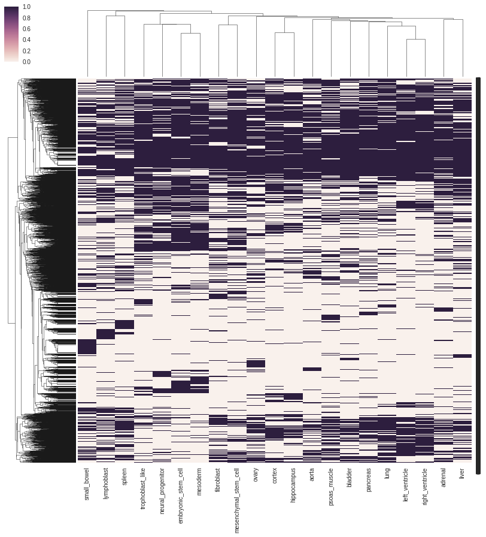

```python
g = sns.clustermap(TAD_master.drop(['chr','start_min','start_max','stop_min','stop_max'],axis=1), figsize=(14,14))
```

different clustering method:

```python
g = sns.clustermap(TAD_master.drop(['chr','start_min','start_max','stop_min','stop_max'],axis=1), method='single', figsize=(14,14))
```

[output not shown]

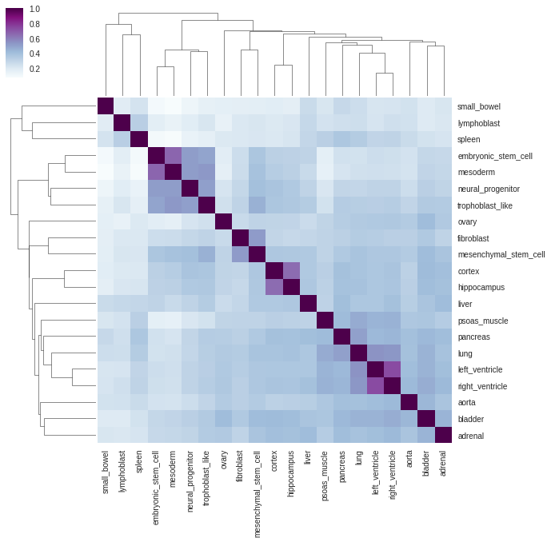

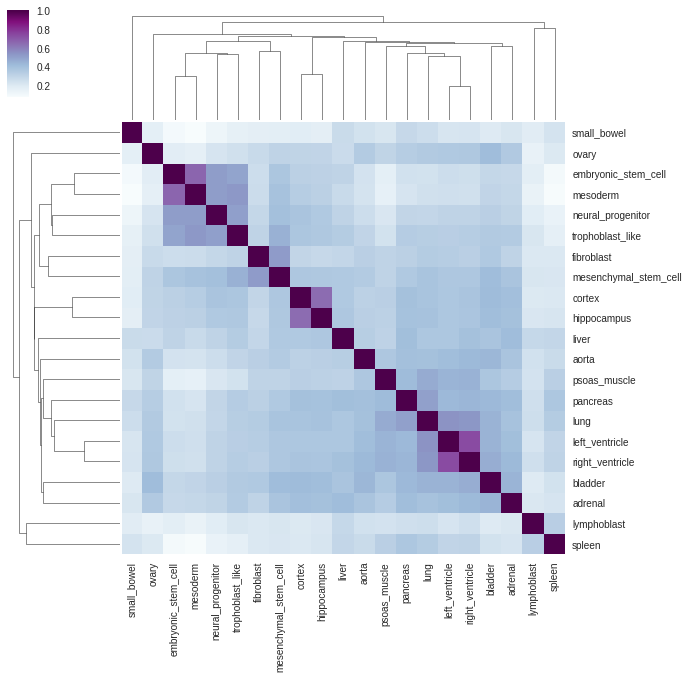

```python
# Correlation matrix between tissue types, two different ways

corr = TAD_master.drop(['chr','start_min','start_max','stop_min','stop_max'],axis=1).corr()

g = sns.clustermap(corr, cmap="BuPu")
g = plt.setp(g.ax_heatmap.yaxis.get_majorticklabels(), rotation=0) # rotating the y-axis labels

g = sns.clustermap(corr, method='single', cmap="BuPu")
g = plt.setp(g.ax_heatmap.yaxis.get_majorticklabels(), rotation=0) # rotating the y-axis labels
```

#### Correlation of TADs across the chromosome

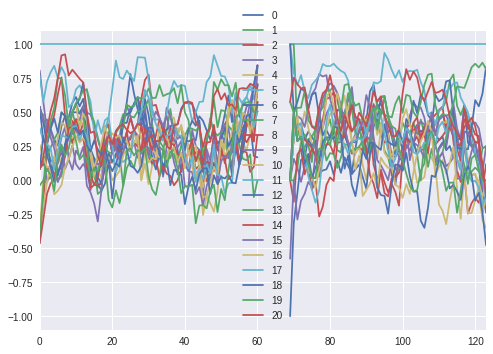

```python
chr1_len = 249250621
win = 10000000
slide = int(win/5)

total_corr = []

# only correlation with embryonic stem cell

for i in range(slide,chr1_len,slide):
        low = i - (win/2)
        high = i + (win/2)
        corr = TAD_master[(TAD_master['chr'] == 'chr1') & (((TAD_master['start_min'] + TAD_master['stop_max'])/2) > low) & (((TAD_master['start_min'] + TAD_master['stop_max'])/2) < high)].drop(['chr','start_min','start_max','stop_min','stop_max'],axis=1).corr().iloc[5]
        total_corr.append(corr)

total_corr = pd.DataFrame(np.vstack(total_corr))
total_corr.plot()
#total_corr['position'] = list(range(slide,chr1_len,slide)
#total_corr.plot()
```

Next steps idea:

```
* Are there cell/tissue-specific genes in areas where TADs are unique for that cell/tissue type?

* Take correlation of all TAD/CTCF structure at multiple different locations

* If the structure is very conserved (high correlation) for all except 1 or 2 tissue types

* Find genes within that TAD (near that boundary) and see if they might be cell/tissue specific - could do this by looking at gene/phenotype ontology
```